# Project №1 Burankova

### Does the number of male and female participants differ in teams at the Winter Olympics?

Each participant is counted only 1 time per game for each team.

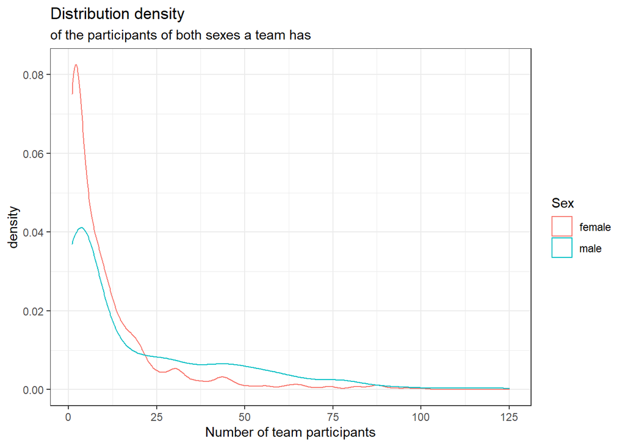

The graph shows that the distribution of participants of both sexes does not have a normal distribution.

Shapiro-Wilk normality test for men in teams p-value = 0 < 2.2 * 10^(-16) for team members distribution (with W = 0.781 and the number of observations - 1007), and p-value = 0 < 2.2 * 10^(-16) for team participants without medals distribution (with W = 0.655 and the number of observations - 713).

The Mann-Whitney U tests the null hypothesis. An alternative hypothesis is that the number of male and female participants differ in teams at the Winter Olympics.

A Mann-Whitney U test showed that there was a significant difference (W = **2.9246^{5}** , p = **4.713574^{-11}**) between the number of male and female participants in teams at the Winter Olympics.

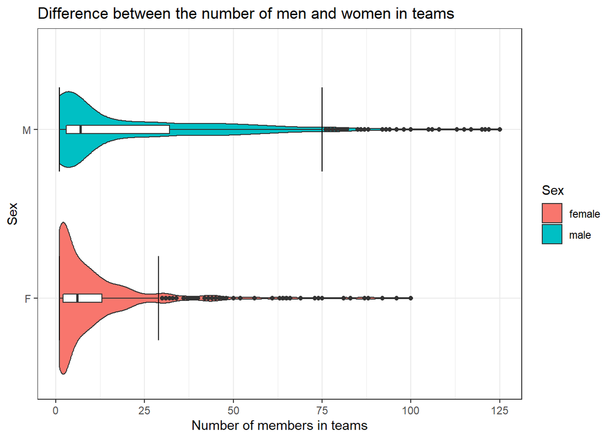

### Is there a difference in the height of women at the winter and summer games?

We have a sufficient number of observations (40786 for Summer season and 8055 for Winter) to consider the distribution of Height variable of female athletes as a normal distribution, which can be seen on the graph.

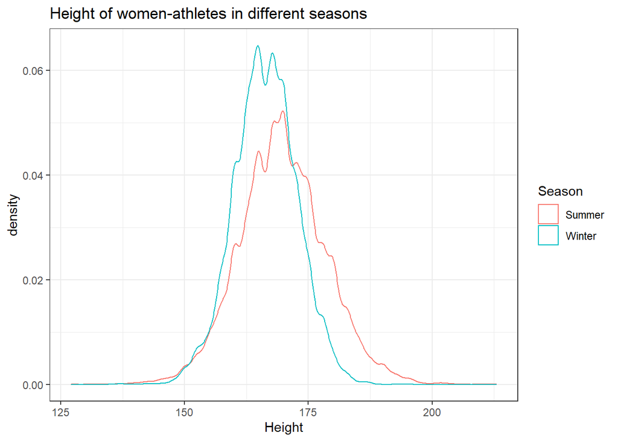

Welch Two Sample t-test (two sided) was performed. Alternative hypothesis - there is a difference in the height of female athletes participating in the winter and summer games.

The value of the t-statistic is **39.264** with **13032.5** degrees of freedom.  
Welch Two Sample t-test showed that there was a significant difference between the the height of female athletes participating in the winter or summer games (p-value = **8.440613^{-319}**).

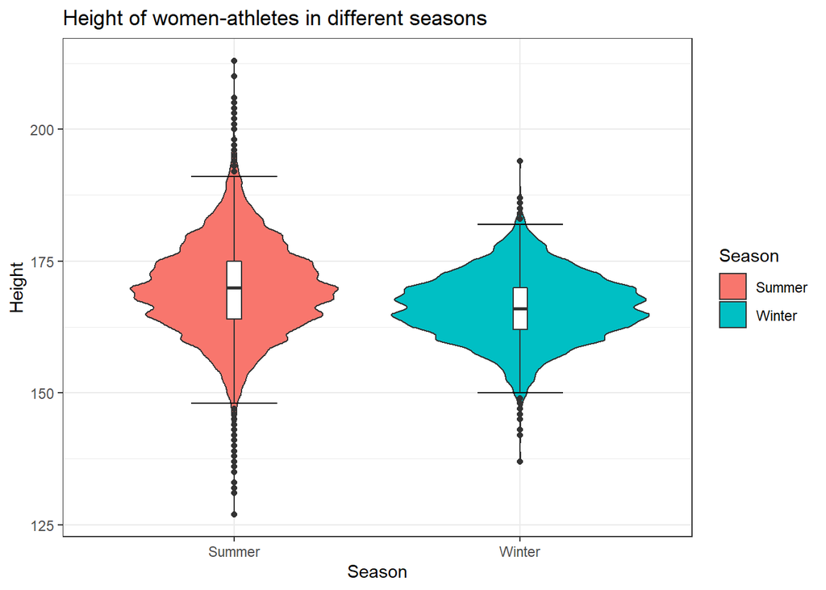

# Conclusion

Data about the Olympic Games from **1896 year to 2016** year was used.

Invalid values in the data have been corrected. There are 271116 rows and 18 variables in the data.

The Height variable was standardized in two ways, including min-max standardization.

The number of teams (countries) participating in the Olympic Games from 1896 to 2016 is **230**. Team has an average of **49** participants (with a standard deviation of 82.05) yearly. Each team won an average of **10.36** medals of any type (with a standard deviation of 30.34) yearly.

Some statistics about the participants in the Olympic Games: - the youngest athletes at the 1992 Olympics is **11** years for men, and **12** years for women.  
- Height variable has:  
- **mean = 179.73** with **standard deviation = 9.46** for men;  
- **mean = 169.19** with **standard deviation = 8.46** for women .

- for women tennis players Height variable has **mean = 171.8** with **standard deviation = 6.6** at the 2000 Olympics.
- the heaviest athlete in the 2006 Olympics participated in the **Skeleton** and had weight 127 kg.
- women received **2249 gold medals** from 1980 to 2010.
- John Aalberg participated in Olympic games 8 times.
- Among the participants from 15 to 55 years old:
  - the smallest group is the 45-55 age group;
  - the most numerous is the 25-34 age group.
- the number of sports at the 2002 Olympics, compared to 1994, has **increased by 3 sports, or 25%**.

For all types of medals, the **average number of medals per participant per country** is 0.0684 (standard deviation 0.1199).

Top 3 countries with the most medals in **Winter Games**:  
- **Gold** medals: Canada, Soviet Union and United States;  
- **Silver** medals: United States, Canada and Norway;  
- **Bronze** medals: Finland, Sweden and United States.

Top 3 countries with the most medals in **Summer** **Games**:  
- **Gold** medals: United States, Soviet Union and United Kingdom;  
- **Silver** medals: United States, United Kingdom and Soviet Union;  
- **Bronze** medals: United States, Soviet Union and Germany.

The following hypotheses were subject to and confirmed by statistical tests:  
- there was a significant difference between **the male athletes height compared with female athletes height**;  
- there was a significant difference between **the male athletes weight compared with female athletes weight**;  
- there was a significant difference between **the male athletes age compared with female athletes age**;  
- there was a significant difference between **the number of male and female participants in teams at the Winter Olympics**;  
- there was a significant difference between **the the height of female athletes participating in the winter or summer games**.

**Teams and Medals**:  
- there is a **strong positive correlation** between the number of team members and the number of their losses;  
- there is a **marked degree of positive correlation** between the number of team members and the number of team medals:  
- there is a marked degree of positive correlation between the number of team members and the number of team Gold medals;  
- there is a marked degree of positive correlation between the number of team members and the number of team Silver medals;  
- there is a marked degree of positive correlation between the number of team members and the number of team Bronze medals;